# EDA for Polviews, Religion, and Region

Joshua Gray

2024-10-21

```r
#Read in data frames and filter down to the variables we want
vars1 <- c('X', 'year', 'id', 'sex', 'age', 'race', 'relig', 'educ', 'income', 'region', 'polviews', 'confed')
vars2 <- c('X', 'year', 'id', 'sex', 'age', 'race', 'relig', 'educ', 'income16', 'region', 'polviews', 'confed')
gss_old <- read.csv("../gss74_80.csv")
gss_old <- gss_old[, vars1]
gss_new <- read.csv("../gss16_22.csv")
gss_new <- gss_new[, vars2]
```

```r
#convert variables to factors with labels
gss_old$region <- factor(gss_old$region, levels = c(1, 2, 3, 4, 5, 6, 7, 8, 9), labels = c("new england", "middle atlantic", "east north central", "west north central", "south atlantic", "east south atlantic", "west south central", "mountain", "pacific"))

gss_new$region <- factor(gss_new$region, levels = c(1, 2, 3, 4, 5, 6, 7, 8, 9), labels = c("new england", "middle atlantic", "east north central", "west north central", "south atlantic", "east south atlantic", "west south central", "mountain", "pacific"))
```

```r
# Encoding variables
gss_new$relig <- case_when(
  gss_new$relig == 1 ~ 'Protestant',
  gss_new$relig == 2 ~ 'Catholic',
  gss_new$relig == 3 ~ 'Jewish',
  gss_new$relig == 4 ~ 'None',
  gss_new$relig == 5 ~ 'Other',
  gss_new$relig == 6 ~ 'Other',
  gss_new$relig == 7 ~ 'Other',
  gss_new$relig == 8 ~ 'Other',
  gss_new$relig == 9 ~ 'Other',
  gss_new$relig == 10 ~ 'Other',
  gss_new$relig == 11 ~ 'Other',
  gss_new$relig == 12 ~ 'Other',
  gss_new$relig == 13 ~ 'Other',
  TRUE ~ NA
)

gss_old$relig <- case_when(
  gss_old$relig == 1 ~ 'Protestant',
  gss_old$relig == 2 ~ 'Catholic',
  gss_old$relig == 3 ~ 'Jewish',
  gss_old$relig == 4 ~ 'None',
  gss_old$relig == 5 ~ 'Other',
  gss_old$relig == 6 ~ 'Other',
  gss_old$relig == 7 ~ 'Other',
  gss_old$relig == 8 ~ 'Other',
  gss_old$relig == 9 ~ 'Other',
  gss_old$relig == 10 ~ 'Other',
  gss_old$relig == 11 ~ 'Other',
  gss_old$relig == 12 ~ 'Other',
  gss_old$relig == 13 ~ 'Other',
  TRUE ~ NA
)

gss_new$income16 <- factor(gss_new$income16, levels = c(1:25), labels = c('Low','Low','Low','Low','Low','Low','Low','Low', 'Lower-Middle','Lower-Middle','Lower-Middle','Lower-Middle','Lower-Middle','Lower-Middle','Lower-Middle', 'Middle','Middle','Middle','Middle','Middle', 'Upper-Middle','Upper-Middle', 'High', 'High', 'High'))
```

# Region (region)

### Description

Here is a map of the country divided into its regions

[figure not shown]

US Regions

### Distribution

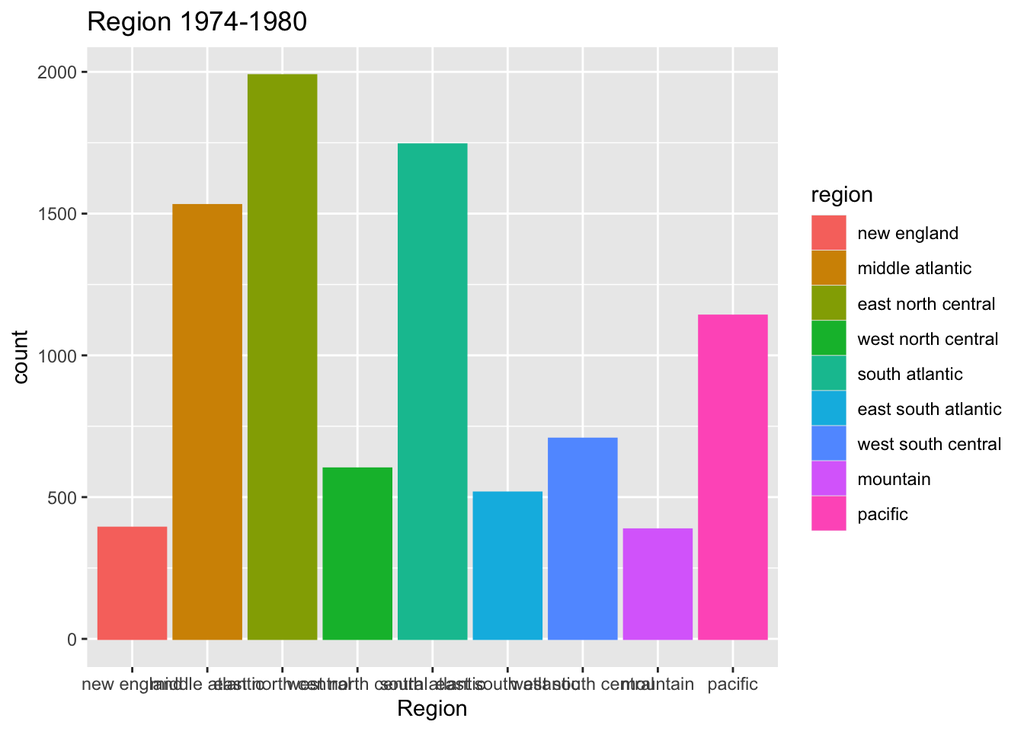

```r
#Plot histograms
ggplot(gss_old, aes(x=region, color=region, fill=region)) + geom_histogram(stat="count") + labs(title = "Region 1974-1980", x="Region")
```

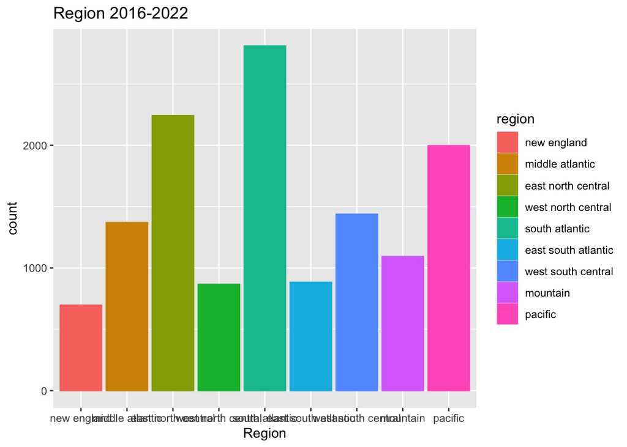

```r
ggplot(gss_new, aes(x=region, color=region, fill=region)) + geom_histogram(stat="count") + labs(title = "Region 2016-2022", x="Region")
```

### Summary

The most frequent region in the 70s is east north central. The most frequent region in the 20s is south atlantic. The least frequent region in the 70’s is mountain. And the least frequent region in the 20s is new england.

### Hypothesis Test (1974-1980)

```r
pol_data <- gss_old[, c('region', 'confed')]
pol_data <- pol_data[complete.cases(pol_data),]

rel_new <- chisq.test(pol_data$region, pol_data$confed)
rel_new
```

```
##
##  Pearson's Chi-squared test
##
## data:  pol_data$region and pol_data$confed
## X-squared = 50.074, df = 16, p-value = 2.231e-05
```

```r
rel_new$observed
```

```
##                      pol_data$confed
## pol_data$region          1    2    3
##   new england           63  223   98
##   middle atlantic      206  820  457
##   east north central   321 1080  531
##   west north central    93  333  154
##   south atlantic       293  915  462
##   east south atlantic   96  270  132
##   west south central   128  368  188
##   mountain              58  195  128
##   pacific              137  588  384
```

### Hypothesis Test (2016-2022)

```r
pol_data <- gss_new[, c('region', 'confed')]
pol_data <- pol_data[complete.cases(pol_data),]

rel_new <- chisq.test(pol_data$region, pol_data$confed)
rel_new
```

```
##
##  Pearson's Chi-squared test
##
## data:  pol_data$region and pol_data$confed
## X-squared = 25.45, df = 16, p-value = 0.06228
```

```r
rel_new$observed
```

```
##                      pol_data$confed
## pol_data$region         1   2   3
##   new england          63 221 186
##   middle atlantic     109 406 389
##   east north central  149 641 693
##   west north central   68 241 251
##   south atlantic      230 767 833
##   east south atlantic  73 245 272
##   west south central  109 433 408
##   mountain             71 307 353
##   pacific             179 577 571
```

### Conclusion

The p-value for the chi-square test of the older time interval indicates that there was a significant relationship between which region a respondent lived in and how they felt about the executive branch. We can neglect the null hypothesis that there is no statistical significance there. However, that is not the case for the more recent time interval. The p-value is greater than 0.05 which means we cannot reject the null hypothesis for the years 2016 through 2022.

# Religion (relig)

### Description

There are several more religions listed in the newer surveys. We decided to combine the less frequent religions into one bucket called “Other” in order to more closely resemble the older surveys.

### Distribution

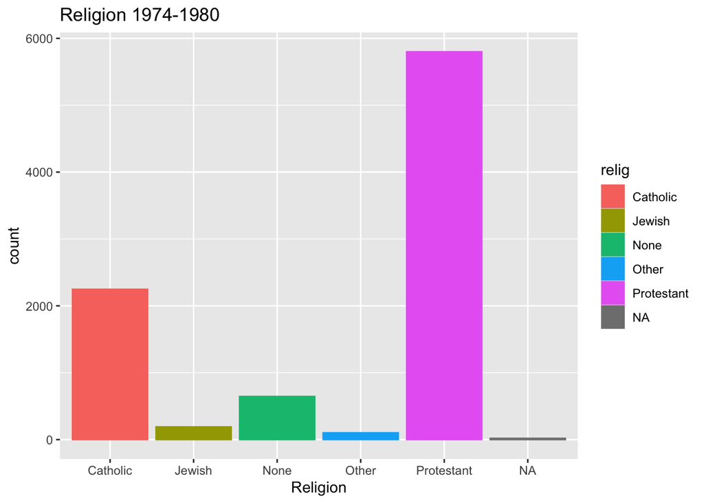

```r
ggplot(gss_old, aes(x=relig, color=relig, fill=relig)) + geom_histogram(stat="count") + labs(title = "Religion 1974-1980", x="Religion")
```

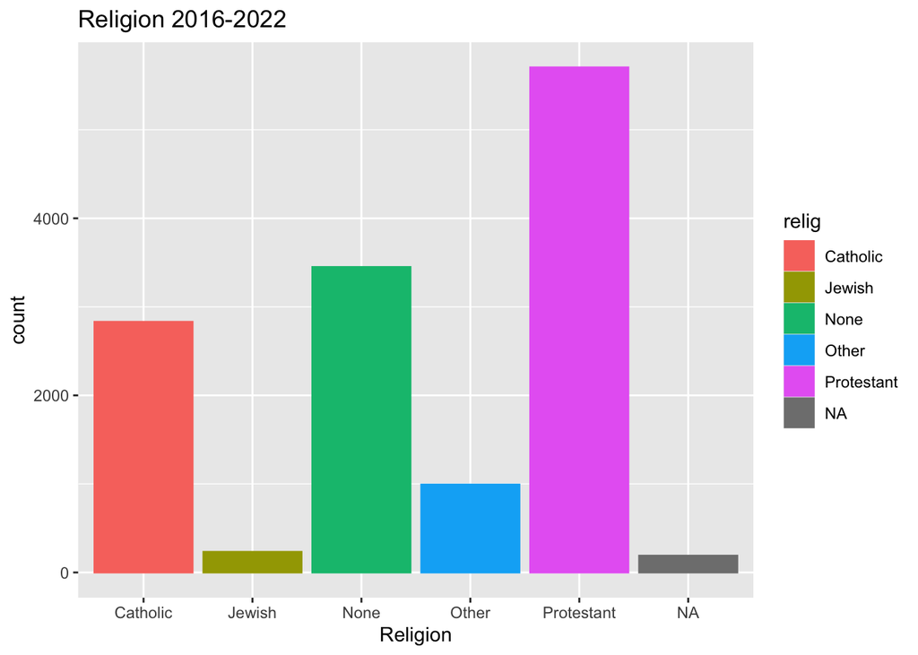

```r
ggplot(gss_new, aes(x=relig, color=relig, fill=relig)) + geom_histogram(stat="count") + labs(title = "Religion 2016-2022", x="Religion")
```

### Summary

The most frequent religion in the early surveys is Protestant. The most frequent religion in the recent surveys is Protestant. While protestant is the most common religion for both time intervals, we see an increase to all other religions in the recent surveys.

### Hypothesis Test (1974 - 1980)

```r
pol_data <- gss_old[, c('relig', 'confed')]
pol_data <- pol_data[complete.cases(pol_data),]

rel_old <- chisq.test(pol_data$relig, pol_data$confed)
rel_old
```

```
##
##  Pearson's Chi-squared test
##
## data:  pol_data$relig and pol_data$confed
## X-squared = 53.269, df = 8, p-value = 9.568e-09
```

```r
rel_old$observed
```

```
##               pol_data$confed
## pol_data$relig    1    2    3
##     Catholic    340 1237  613
##     Jewish       19   99   64
##     None         65  315  248
##     Other        13   58   26
##     Protestant  956 3076 1576
```

### Hypothesis Test (2016 - 2022)

```r
pol_data <- gss_new[, c('relig', 'confed')]
pol_data <- pol_data[complete.cases(pol_data),]

rel_new <- chisq.test(pol_data$relig, pol_data$confed)
rel_new
```

```
##
##  Pearson's Chi-squared test
##
## data:  pol_data$relig and pol_data$confed
## X-squared = 25.571, df = 8, p-value = 0.001243
```

```r
rel_new$observed
```

```
##               pol_data$confed
## pol_data$relig    1    2    3
##     Catholic    243  855  754
##     Jewish       24   75   53
##     None        269  981 1032
##     Other        76  284  307
##     Protestant  422 1590 1760
```

### Conclusion

As a result of our hypothesis tests for religion, we can reject the null hypothesis and claim that there is a significant relationship between a respondent’s religion and how they feel about our executive branch.

# Political Spectrum (polviews)

### Descrpition

For this variable, respondents give a number between 1 and 7 according to where they fall on the political spectrum with 1 being extremely progressive and 7 being extremely conservative.

### Distribuion

[figure not shown]

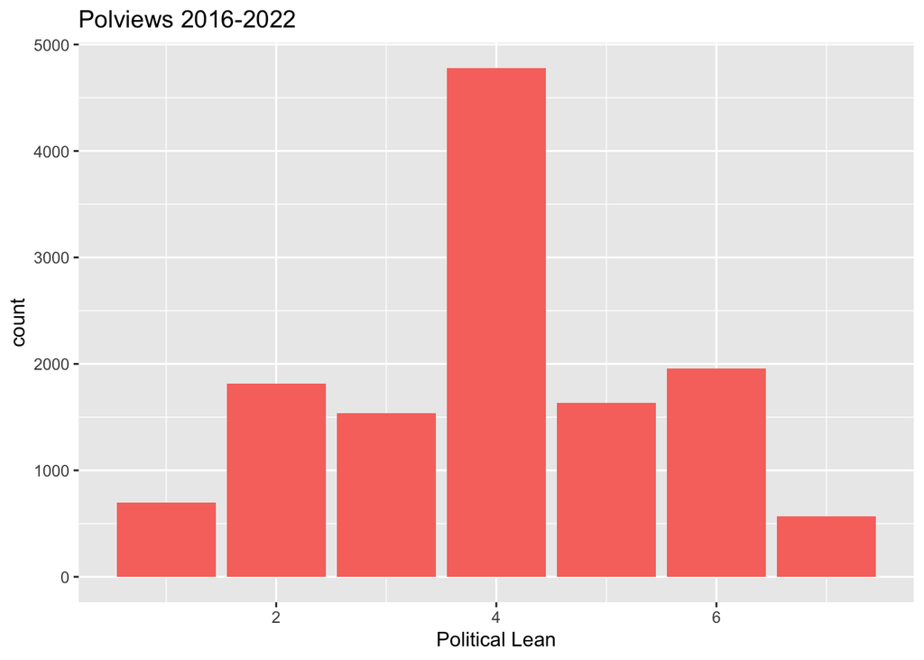

### Hypothesis testing (1974 - 1980)

```r
pol_data <- gss_old[, c('polviews', 'confed')]
pol_data <- pol_data[complete.cases(pol_data),]

rel_old <- chisq.test(pol_data$polviews, pol_data$confed)
rel_old
```

```
##
##  Pearson's Chi-squared test
##
## data:  pol_data$polviews and pol_data$confed
## X-squared = 52.41, df = 12, p-value = 5.244e-07
```

```r
rel_old$observed
```

```
##                  pol_data$confed
## pol_data$polviews    1    2    3
##                 1   25   89   77
##                 2  154  493  329
##                 3  181  726  325
##                 4  510 1867  929
##                 5  246  797  370
##                 6  173  536  303
##                 7   44   91   73
```

### Hypothesis testing (2016 - 2022)

```r
pol_data <- gss_new[, c('polviews', 'confed')]
pol_data <- pol_data[complete.cases(pol_data),]

rel_old <- chisq.test(pol_data$polviews, pol_data$confed)
rel_old
```

```
##
##  Pearson's Chi-squared test
##
## data:  pol_data$polviews and pol_data$confed
## X-squared = 335.51, df = 12, p-value < 2.2e-16
```

```r
rel_old$observed
```

```
##                  pol_data$confed
## pol_data$polviews    1    2    3
##                 1   82  168  192
##                 2  242  559  403
##                 3  135  516  382
##                 4  313 1502 1328
##                 5   90  472  541
##                 6  117  418  766
##                 7   45  110  222
```

### Conclusion

From our chi-squared tests here, both p-values indicate a significant relationship between how a respondent identifies and how they feel about the executive branch of the government.